# hw5_repo+code

JiwenZhang, 21110980015

2022/4/12

## 01 准备工作

```r
# 清除工作环境
cat("\014");rm(list = ls())
```

```r
# 设置工作目录
setwd("../Homework 5")
```

```r
# 加载需要的包
library(readxl)
library(ggplot2)
library(dplyr)
library(gridExtra)
library(jiebaR)
library(wordcloud2)
library(text2vec)
library(e1071)
library(caret)
```

## 02 读取数据

首先将数据读入，并查看数据的基本形式。

```r
catalog <- read_excel("catalogs.xlsx")
# 查看数据
head(catalog)
```

```
## # A tibble: 6 x 4
##   name                                                  first second  third
##   <chr>                                                 <chr> <chr>   <chr>
## 1 双汇 猪舌 700g/袋                                     生鲜  猪牛羊肉… 猪肉
## 2 （满38减10）黑猪腊肉 湘西腊肉 即食小吃食猪肉干肉脯湖南张家界土家 香辣味… 生鲜  猪牛羊肉… 猪肉
## 3 精气神 猪肋排段（排骨） 400g/袋 山黑猪  黑猪肉 林间散养… 生鲜  猪牛羊肉… 猪肉
## 4 双汇 猪五花肉片 300g/袋 整肉原切 火锅食材             生鲜  猪牛羊肉… 猪肉
## 5 农家散养新鲜现杀黑土猪肉 纯瘦肉  500g                 生鲜  猪牛羊肉… 猪肉
## 6 精气神 猪腿肉 400g/袋 山黑猪 黑猪肉 林间散养（2件起售）… 生鲜  猪牛羊肉… 猪肉
```

## 03 描述性分析

### 3.1 二级分布

我们首先采用 dplyr 包，计算了“生鲜”和“食品饮料、保健食品”两个一级品类下二级品类的分布。

```
## # A tibble: 13 x 4
## # Groups:   first [2]
##    first              second       n   freq
##    <chr>              <chr>    <int>  <dbl>
##  1 生鲜               冷冻食品  1088 0.0530
##  2 生鲜               水果      5635 0.275
##  3 生鲜               海鲜水产  4697 0.229
##  4 生鲜               猪牛羊肉  1829 0.0891
##  5 生鲜               禽肉蛋品  1920 0.0935
##  6 生鲜               蔬菜      5006 0.244
##  7 生鲜               饮品甜品   349 0.0170
##  8 食品饮料、保健食品 休闲食品  6811 0.139
##  9 食品饮料、保健食品 地方特产 12577 0.257
## 10 食品饮料、保健食品 粮油调味 10288 0.210
## 11 食品饮料、保健食品 茗茶     12508 0.255
## 12 食品饮料、保健食品 食品礼券  1921 0.0392
## 13 食品饮料、保健食品 饮料冲调  4865 0.0993
```

然后，绘制饼图。

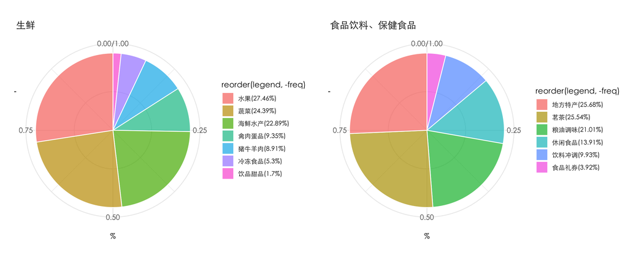

可以发现，在“生鲜”品类中，占据大头的商品是水果和蔬菜，占比较少的是冷冻食品和饮品甜品；在“食品饮料”品类中，占据大头的是地方特产、茗茶和粮油调味品，占比较低的是食品礼券。两个品类在商品分布上有明显的区别。

### 3.2 分词

首先使用 jieba 分词对商品名称进行分词处理。这里，我采用的停用词主要是一些量词，例如“袋、瓶、盒”等。

```r
##初始化分词工具
seg <- worker(bylines = T)

# 读入自定义词典和停用词
new_words <- read.table('userdict.dat', header = F, stringsAsFactors = F)
my_stop_words <- read.table('stop_words.dat', header = F, stringsAsFactors = F)

# 将词典加入分词引擎
new_user_word(seg, new_words$V1)
```

```
## [1] TRUE
```

```r
# 进行分词
catalog$name_seg <- segment(as.character(catalog$name), seg)

# 删除停用词
catalog$name_seg <-filter_segment(catalog$name_seg, my_stop_words$V1)
```

然后计算得到“生鲜”和“食品饮料、保健食品”类别下每个商品名称分词后单词的数量。

```r
catalog$seg_cnt <- sapply(catalog$name_seg, length)

head(catalog, 10)
```

```
## # A tibble: 10 x 6
##    name                                first second  third name_seg seg_cnt
##    <chr>                               <chr> <chr>   <chr> <list>     <int>
##  1 双汇 猪舌 700g/袋                   生鲜  猪牛羊肉… 猪肉  <chr [4…       4
##  2 （满38减10）黑猪腊肉 湘西腊肉 即食小吃食猪肉干肉脯湖南张家界土… 生鲜  猪牛羊肉… 猪肉  <chr [1…      18
##  3 精气神 猪肋排段（排骨） 400g/袋 山黑猪  黑猪肉 林间散养… 生鲜  猪牛羊肉… 猪肉  <chr [1…      12
##  4 双汇 猪五花肉片 300g/袋 整肉原切 火锅食材… 生鲜  猪牛羊肉… 猪肉  <chr [9…       9
##  5 农家散养新鲜现杀黑土猪肉 纯瘦肉  500g… 生鲜  猪牛羊肉… 猪肉  <chr [1…      10
##  6 精气神 猪腿肉 400g/袋 山黑猪 黑猪肉 林间散养（2件起售）… 生鲜  猪牛羊肉… 猪肉  <chr [1…      14
##  7 土猪肉新鲜现杀农家散养土猪排骨纯粮食喂养五花肉笨猪肉500g… 生鲜  猪牛羊肉… 猪肉  <chr [1…      15
##  8 金锣 培根 精致培根 500g/袋 烧烤食材 生鲜  猪牛羊肉… 猪肉  <chr [7…       7
##  9 【冷鲜肉】对面小城 散养黑土猪里脊肉通脊 大里脊 1kg家庭装… 生鲜  猪牛羊肉… 猪肉  <chr [1…      15
## 10 精气神 猪肉馅(90%瘦肉) 400g/袋 山黑猪 黑猪肉  林间散… 生鲜  猪牛羊肉… 猪肉  <chr [1…      12
```

### 3.3 单词数量分布

使用 ggplot 函数绘制两个一级品类商品名称分词后单词数量的直方图。

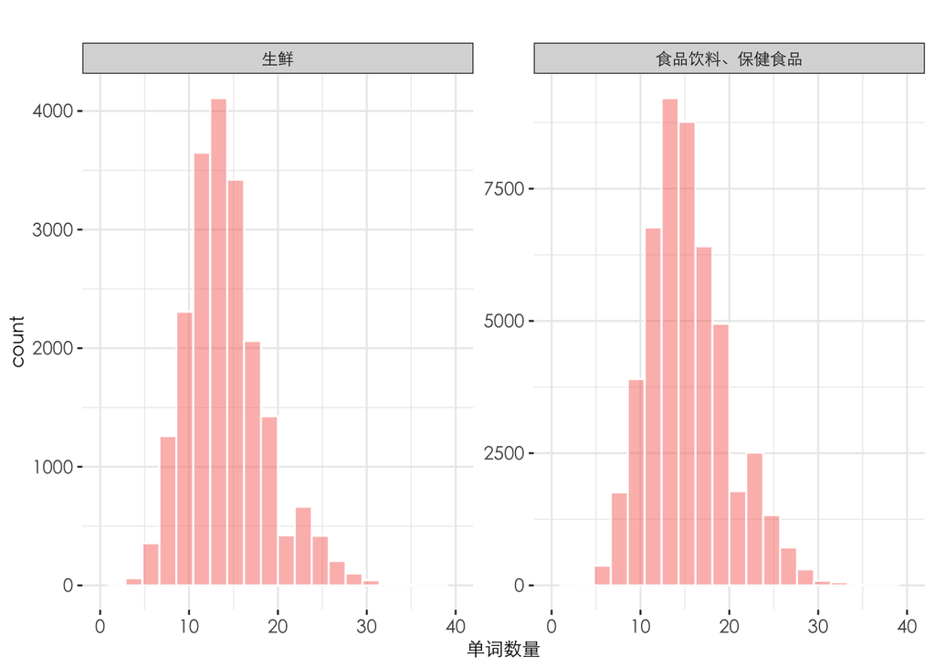

```r
ggplot(catalog) +
  geom_histogram(aes(seg_cnt, fill="#FF6A6A"),
                 bins = 22, color = "white", alpha = 0.5, show.legend = FALSE) +
  labs(x = "单词数量", y = "count", title="") +
  xlim(0, 40) +
  theme_bw() +
  theme(panel.border=element_blank(),
        text = element_text(family = "STXihei"),
        axis.title = element_text(size = 10),
        axis.text = element_text(size = 10)) +
  facet_wrap(~first, scales = "free_y")
```

### 3.4 可视化：词云图

绘制“食品饮料、保健食品”类别下三级品类“牛奶乳品”和“成人奶粉”商品名称分词后的 top100 高频词的词云图。(我们在这里同时也做了一些预处理，去除了词语中的纯字母、数字组合。)

```r
# 过滤字母、数字组合
pattern <- "[a-zA-Z0-9_]+"

word_lists <- catalog[catalog$third == "牛奶乳品",]$name_seg
words = c()
for (i in 1:length(word_lists)){
  w_list <- word_lists[i]
  words <- c(words, w_list[[1]])
}
words <- words[!grepl(pattern, words)]
word_freqs <- arrange(freq(words), -freq)

print("牛奶乳品")
```

```
## [1] "牛奶乳品"
```

```r
wordcloud2(data = head(word_freqs, 100))
```

[interactive chart not shown]

```r
# 过滤字母、数字组合
pattern <- "[a-zA-Z0-9_]+"

word_lists <- catalog[catalog$third == "成人奶粉",]$name_seg
words = c()
for (i in 1:length(word_lists)){
  w_list <- word_lists[i]
  words <- c(words, w_list[[1]])
}
words <- words[!grepl(pattern, words)]
word_freqs <- arrange(freq(words), -freq)

print("成人奶粉")
```

```
## [1] "成人奶粉"
```

```r
wordcloud2(data = head(word_freqs, 100))
```

[interactive chart not shown]

从两幅词云图中，可发现“牛奶乳品”类商品较为关注产品的口味、包装是否较好、是否品牌和是否包邮；而“成人奶粉”类商品主要关注奶粉的营养成分、适用人群、是否进口等。这可能是因为牛奶乳品具有一定的礼品用途，而成人奶粉多为自购需求。

## 04 数据预处理

### 4.1 数据集拆分

```r
set.seed(666)

id <- sample(1:nrow(catalog), 0.7 * nrow(catalog), F)
train <- catalog[id, ]
test <- catalog[-id, ]

train$id <- as.character(1:nrow(train))
test$id <- as.character(1:nrow(test))
```

### 4.2 停用词

找到分词结果中的纯数字或字母，存入stop_words。

```r
# 字母组合、数字组合等
pattern1 <- "^([a-z]|[A-Z]])+$"
pattern2 <- '^[0-9]+(\\.)?[0-9]*(-)?[0-9]*(\\.)?[0-9]*$'

stop_words <- unique(unlist(train$name_seg))
stop_words <- stop_words[grepl(pattern1, stop_words)|grepl(pattern2, stop_words)]

# stop_words中可能存在一些包含在自定义词典中的专有名词，去掉
stop_words <- setdiff(stop_words, new_words)

# 设置分词迭代器
it_train <- itoken(train$name_seg, ids = train$id)
it_test <- itoken(test$name_seg, ids = test$id)
vocab <- create_vocabulary(it_train)
```

### 4.3 文档-词频矩阵

修建低频、高频词，保留高频词中的 top1000 的词语，作为分类器的特征。

```r
# 修剪低频词、高频词
pruned_vocab <- prune_vocabulary(vocab, doc_count_min = 10, doc_proportion_max = 0.75)
pruned_vocab <- pruned_vocab[!(pruned_vocab$term %in% stop_words), ]
# 保留词频前1000的词语
pruned_vocab <- pruned_vocab[order(pruned_vocab$term_count, decreasing = T), ]
pruned_vocab <- pruned_vocab[1:1000, ]
# 初步形成语料文件
vectorizer <- vocab_vectorizer(pruned_vocab)
```

根据语料文件生成文档-词频矩阵。

```r
# 文档-词频矩阵
dtm_train <- create_dtm(it_train, vectorizer)
dtm_test <- create_dtm(it_test, vectorizer)
dtm_train <- as.matrix(dtm_train)
dtm_test <- as.matrix(dtm_test)

# 转化为0-1矩阵
dtm_train[dtm_train > 1] <- 1
dtm_test[dtm_test > 1] <- 1
dtm_train <- apply(dtm_train, 2, as.factor)
dtm_test <- apply(dtm_test, 2, as.factor)

print(dim(dtm_train))
```

```
## [1] 48645  1000
```

```r
print(dim(dtm_test))
```

```
## [1] 20849  1000
```

## 05 朴素贝叶斯分类器

### 5.1 模型建立

以文档词频矩阵为自变量，以每个商品名称对应的二级分类为因变量，建立自动化分类模型。以“食品饮料、保健食品”类为例，对训练集建立朴素贝叶斯分类器。

```r
train_food <- train[train$first == '食品饮料、保健食品', ]
test_food <- test[test$first == '食品饮料、保健食品', ]

dtm_train_food <- dtm_train[train$first == '食品饮料、保健食品', ]
dtm_test_food <- dtm_test[test$first == '食品饮料、保健食品', ]

# 根据训练集数据，建立朴素贝叶斯分类器
nb <- naiveBayes(x = dtm_train_food, y = as.factor(train_food$second), laplace = 0)

# 预测
train_pred <- predict(nb, dtm_train_food, type = 'class')
test_pred <- predict(nb, dtm_test_food, type = 'class')
```

```r
# 准确率
train_accuracy <- sum(as.character(train_food$second) == as.character(train_pred)) / nrow(train_food)
test_accuracy <- sum(as.character(test_food$second) == as.character(test_pred)) / nrow(test_food)

print(paste0('训练集 -- 二级品类Acc：', round(train_accuracy, 3)))
```

```
## [1] "训练集 -- 二级品类Acc：0.856"
```

```r
print(paste0('测试集 -- 二级品类Acc：', round(test_accuracy, 3)))
```

```
## [1] "测试集 -- 二级品类Acc：0.855"
```

### 5.2 模型评测：混淆矩阵

#### 5.2.1 训练集

```r
cm <- confusionMatrix(data=train_pred, reference=as.factor(train_food$second))
cm
```

```
## Confusion Matrix and Statistics
##
##           Reference
## Prediction 休闲食品 地方特产 粮油调味 茗茶 食品礼券 饮料冲调
##   休闲食品     4023      779      143   42       32       13
##   地方特产      558     6464      653  132       36       44
##   粮油调味       85     1148     6126  143        6       67
##   茗茶           11      204       80 8267        5       27
##   食品礼券       29      156       54    8     1278        4
##   饮料冲调      110      109      154  112       17     3262
##
## Overall Statistics
##
##                Accuracy : 0.8557
##                  95% CI : (0.8519, 0.8594)
##     No Information Rate : 0.2577
##     P-Value [Acc > NIR] : < 2.2e-16
##
##                   Kappa : 0.8192
##
##  Mcnemar's Test P-Value : < 2.2e-16
##
## Statistics by Class:
##
##                      Class: 休闲食品 Class: 地方特产 Class: 粮油调味
## Sensitivity                   0.8353          0.7296          0.8497
## Specificity                   0.9659          0.9442          0.9467
## Pos Pred Value                0.7995          0.8196          0.8087
## Neg Pred Value                0.9730          0.9096          0.9596
## Prevalence                    0.1401          0.2577          0.2097
## Detection Rate                0.1170          0.1880          0.1782
## Detection Prevalence          0.1464          0.2294          0.2203
## Balanced Accuracy             0.9006          0.8369          0.8982
##                      Class: 茗茶 Class: 食品礼券 Class: 饮料冲调
## Sensitivity               0.9498         0.93013         0.95464
## Specificity               0.9873         0.99240         0.98379
## Pos Pred Value            0.9620         0.83584         0.86663
## Neg Pred Value            0.9831         0.99708         0.99494
## Prevalence                0.2532         0.03996         0.09939
## Detection Rate            0.2405         0.03717         0.09488
## Detection Prevalence      0.2500         0.04447         0.10948
## Balanced Accuracy         0.9685         0.96126         0.96921
```

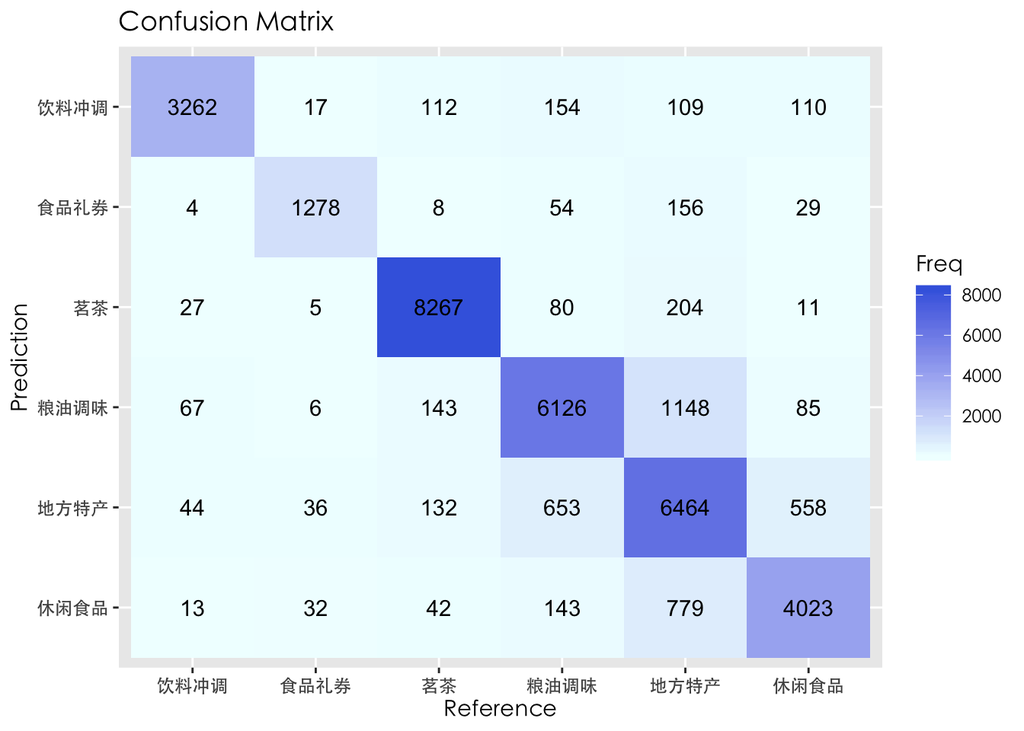

```r
# extract the confusion matrix values as data.frame
cm_d <- as.data.frame(cm$table)

# plotting the matrix
par(family='STHeiti')
ggplot(data = cm_d, aes(x=Reference , y=Prediction, fill=Freq)) +
  geom_tile() +
  xlim(rev(levels(cm_d$Reference))) +
  geom_text(aes(label=Freq)) +
  theme_grey(base_family = "STHeiti") +
  scale_fill_gradient(low="Azure", high="royalblue") +
  ggtitle("Confusion Matrix")
```

#### 5.2.2 测试集

```r
cm <- confusionMatrix(data=test_pred, reference=as.factor(test_food$second))
cm
```

```
## Confusion Matrix and Statistics
##
##           Reference
## Prediction 休闲食品 地方特产 粮油调味 茗茶 食品礼券 饮料冲调
##   休闲食品     1651      323       60   20       15        7
##   地方特产      231     2701      275   54        8       15
##   粮油调味       29      500     2623   69        1       40
##   茗茶            7       95       32 3610        4       17
##   食品礼券       18       60       19    2      514        0
##   饮料冲调       59       38       69   49        5     1369
##
## Overall Statistics
##
##                Accuracy : 0.8546
##                  95% CI : (0.8488, 0.8603)
##     No Information Rate : 0.2607
##     P-Value [Acc > NIR] : < 2.2e-16
##
##                   Kappa : 0.8174
##
##  Mcnemar's Test P-Value : < 2.2e-16
##
## Statistics by Class:
##
##                      Class: 休闲食品 Class: 地方特产 Class: 粮油调味
## Sensitivity                   0.8276          0.7267          0.8522
## Specificity                   0.9663          0.9464          0.9445
## Pos Pred Value                0.7953          0.8225          0.8041
## Neg Pred Value                0.9725          0.9101          0.9598
## Prevalence                    0.1367          0.2548          0.2110
## Detection Rate                0.1132          0.1851          0.1798
## Detection Prevalence          0.1423          0.2251          0.2236
## Balanced Accuracy             0.8969          0.8365          0.8983
##                      Class: 茗茶 Class: 食品礼券 Class: 饮料冲调
## Sensitivity               0.9490         0.93967         0.94544
## Specificity               0.9856         0.99295         0.98326
## Pos Pred Value            0.9588         0.83850         0.86155
## Neg Pred Value            0.9821         0.99764         0.99392
## Prevalence                0.2607         0.03749         0.09925
## Detection Rate            0.2474         0.03523         0.09384
## Detection Prevalence      0.2581         0.04202         0.10892
## Balanced Accuracy         0.9673         0.96631         0.96435
```

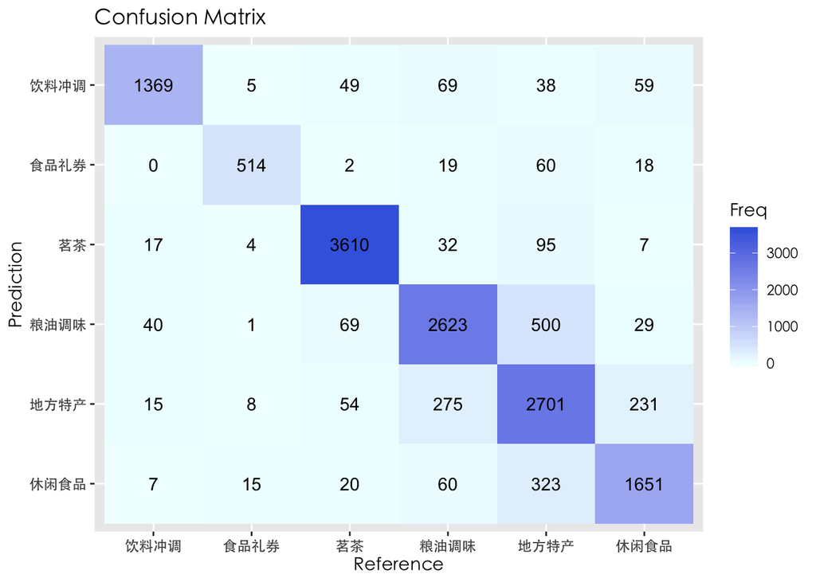

```r
# extract the confusion matrix values as data.frame
cm_d <- as.data.frame(cm$table)

# plotting the matrix
par(family='STHeiti')
ggplot(data = cm_d, aes(x=Reference , y=Prediction, fill=Freq)) +
  geom_tile() +
  xlim(rev(levels(cm_d$Reference))) +
  geom_text(aes(label=Freq)) +
  theme_grey(base_family = "STHeiti") +
  scale_fill_gradient(low="Azure", high="royalblue") +
  ggtitle("Confusion Matrix")
```

综合准确率、混淆矩阵，可以发现：在训练集上分类准确率较高的品类，在测试集上分类准确率也较高，例如茗茶、食品礼券、饮料冲调。 此外，粮油调味和地方特产两类容易混淆，这可能是由于粮油调味商品的名称内往往会包含一些地名导致的。地方特产同时和休闲食品也较易产生混淆，这可能是由于两个品类中的商品有部分叫相似度较高。